# TrenaMultiScore Demo: KLF1 regulation in Erythropoiesis

### Overview

Here are some of the annotations we have recently employed:

- mRNA expression correlation between the FIMO-predicted TF and the target gene
- FIMO sequence match score
- ChIP hits from ReMap2020
- distance to target gene’s TSS
- Phas conservation
- cognate protein expression
- detailed GeneHancer relations
- methylation

These regions, annotated these ways, are expressed as an R data.frame. You may, in an exploratory mode, or perhaps with a strict set of annotation filters, identify TFs of interest by subsetting that data.frame (aka “tms table”) using the venerable R function **subset**.

In this demonstration, we use a few annotations, strict filtering, to identify two candidate TFs for KLF1 across the erythropoiesis time course.

### A Simple Demo

We begin by loading the two fundamental packages:

- TrenaMultiScore for algorithms and operations
- TrenaProjectErythropoiesis for a range of Brand Lab data

Because it is complex and time-consuming to build these R packages, and all of their dependencies, I will soon provide you with pre-build Docker images.

```r
suppressWarnings(
suppressMessages({
   library(TrenaMultiScore)
   library(TrenaProjectErythropoiesis)
   library(factoextra)
     # Extract and Visualize the Results of Multivariate Data Analyses

tpe <- TrenaProjectErythropoiesis()
tms <- TrenaMultiScore(tpe,  "KLF1")
}))
```

The GeneHancer project curates genome-wide enhancer/target gene combinations. Here we learn the full region over which enhancers annotated to KLF1 have been found or predicted. We restrict our subsequent analysis to this cis region. (You can also specify this “genomic region of regulatory interest” manually, to include larger or smaller regions, or regions on other chromosomes.)

```r
loc <- getGeneHancerRegion(tms)
print(sprintf("genehancer genomic span: %d kb", with(loc, 1 + end - start)))
```

```
## [1] "genehancer genomic span: 202723 kb"
```

The Brand Lab provides ATAC-Seq data. Here we use the version which merges open chromatin across all timepoints in the erythropoiesis timecourse.

```r
findOpenChromatin(tms)  # consults atac-seq
```

```
## [1] 126
```

[FIMO](https://meme-suite.org/meme/doc/fimo.html) scores transcription factor binding PWMs against genomic sequence. We do that now, with a [MotifDB](https://www.bioconductor.org/packages/release/bioc/html/MotifDb.html) PWMs, where the target genomic sequences are only the ATAC-Seq hits in the 203 kb genehancer genomic span.

```r
suppressWarnings(
suppressMessages({
  findFimoTFBS(tms, fimo.threshold=1e-3)
  }))
```

TrenaMultiScore’s fundamental data structure is a “feature table” - a simple R data.frame. It has one row for every FIMO match in any Brand Lab ATAC-Seq hit in the genehancer-derived genomic region upstrean and downstream of KLF1. It has a minimum of 9 columns - but in practice, many more, as you will see below, as we add columns to those basic 9. First, however, let us look at those basic 9.

```r
tbl = getMultiScoreTable(tms)
rownames(tbl) = NULL
print(sprintf("rows: %d   cols: %d",   nrow(tbl), ncol(tbl)))
```

```
## [1] "rows: 3956   cols: 9"
```

First 6 rows

| chrom | start | end | tf | strand | fimo_score | fimo_pvalue | matched_sequence | motif_id |
| --- | --- | --- | --- | --- | --- | --- | --- | --- |
| chr19 | 12881438 | 12881445 | NR4A2 | + | 8.34444 | 6.08e-04 | GAGGCCAG | Mmusculus;Rnorvegicus;Hsapiens-jaspar2018-NR4A2-MA0160.1 |
| chr19 | 12881438 | 12881452 | TP53 | - | 1.97753 | 9.07e-04 | GCCAGTCCTGGCCTC | Hsapiens-jaspar2018-TP53-MA0106.2 |
| chr19 | 12881444 | 12881456 | SMAD2::SMAD3::SMAD4 | + | 10.23600 | 8.89e-05 | AGGACTGGCACCT | Hsapiens-jaspar2018-SMAD2::SMAD3::SMAD4-MA0513.1 |
| chr19 | 12881444 | 12881458 | RFX5 | + | 7.24719 | 3.16e-04 | AGGACTGGCACCTGG | Hsapiens-jaspar2018-RFX5-MA0510.1 |
| chr19 | 12881444 | 12881455 | PBX2 | + | 7.52846 | 4.98e-04 | AGGACTGGCACC | Hsapiens-jaspar2018-PBX2-MA1113.1 |
| chr19 | 12881446 | 12881464 | CTCF | - | 5.44944 | 2.63e-04 | AAGGCGCCAGGTGCCAGTC | Hsapiens-jaspar2018-CTCF-MA0139.1 |

```r
addChIP(tms)
```

```
## [1] select * from chipseq where chrom='chr19' and start >= 12880438 and endpos <= 13080756
## [1] ChIP-seq hits: 24896
```

```r
print(sprintf("ncol(tbl): %d", ncol(getMultiScoreTable(tms))))
```

```
## [1] "ncol(tbl): 10"
```

Add distance to KLF1 TSS

```r
addDistanceToTSS(tms)
print(sprintf("ncol(tbl): %d", ncol(getMultiScoreTable(tms))))
```

```
## [1] "ncol(tbl): 11"
```

One of the better clues to regulatory relationship of TF to target gene lies in patterns of mRNA co-expression. Add that information now.

```r
mtx <- getExpressionMatrix(tpe, "brandLabDifferentiationTimeCourse-27171x28")
addGeneExpressionCorrelations(tms, mtx)
print(sprintf("ncol(tbl): %d", ncol(getMultiScoreTable(tms))))
```

```
## [1] "ncol(tbl): 12"
```

We have more established annotations (columns) we can add to this table. And many more *possible* annotaions, qualitative or quantitative, all easily accomodated by TrenaMultiScore.

Let us now extract the current table, and query it for TF/KLF1 associations. This is necessarily an exploratory process - one that is informed by your biological sensibility, experience and intuition. Here are a few steps in one such exploration.

Find all the TF binding sites:

- acceptable FIMO score for a TFBS in an ATAC-Seq hit
- TFBS within 1000 bases of KLF1’s TSS
- TF and KLF1 have a very strong corrleation

```r
tbl <- getMultiScoreTable(tms)
tbl.strong <- subset(tbl, chip & abs(cor) > 0.7 & fimo_pvalue < 1e-3 & abs(tss) < 1000)
print(table(tbl.strong$tf))
```

```
##
##  E2F4 TFDP1
##     2     1
```

Thus, with these strict filtering criteria, applied via the standard R function **subset**, we find two interesting binding sites for E2F4, and one for TFDP1. We note that these two putative TFs are variously described, in a casual google search, as [dimer parters](https://www.uniprot.org/uniprotkb/Q16254/entry). You may know a lot about this already!

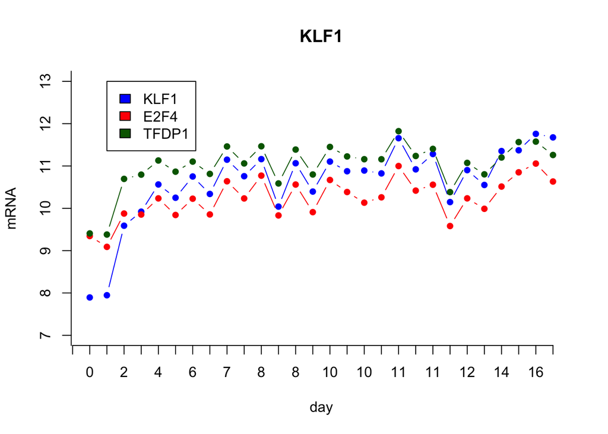

```r
plot(mtx["KLF1",], type="b", col="blue", pch=16, axes=FALSE,
      xlab="day", ylab="mRNA", ylim=c(7,13), main="KLF1")
dayNames = colnames(mtx)
dayNames = sub("day", "", dayNames)
dayNames = sub("\\.r[12]", "", dayNames)
axis(1, at=0:28, labels = c("", dayNames))
axis(2, at=4:14, labels=as.character(4:14))
lines(mtx["E2F4",], type="b", pch=16, col="red")
lines(mtx["TFDP1",], type="b", pch=16, col="darkgreen")
legend(2, 13, c("KLF1", "E2F4", "TFDP1"), c("blue", "red", "darkgreen"))
```